# simple RDA

Pablo E. Gutiérrez-Fonseca

25 November, 2021

#### Primer paso: cargar las librerias que necesitas.

```r
library(ggplot2)
library(dplyr)
library(vegan)
```

#### Segundo paso: cargar los datos.

```r
species=read.csv("D:/Curriculum/07_ Cursos/Course_Multivariate_Stat_for_Ecological_Data/data/RDA_species.csv", header=T, row.names=NULL, sep=",")
env=read.csv("D:/Curriculum/07_ Cursos/Course_Multivariate_Stat_for_Ecological_Data/data/RDA_environmetal.csv", header=T, row.names=NULL, sep=",")
```

#### Before we can use this explanatory matrix we need to check that its rows are in the same order as our response matrix

all.equal(rownames(species), rownames(env))

```r
all.equal(rownames(species), rownames(env))
```

```
## [1] TRUE
```

#### Remover la columna de sitos.

```r
species_1 <- dplyr::select(species, -site)
env_1 <- dplyr::select(env, -site)
```

#### Transformar datos.

Hellinger es una transformacion recomendada por Legendre & Callagher (2001) en datos de abundancia y con una respuesta lineal

```r
spec.hel <- vegan::decostand(species_1, method = "hellinger")
```

#### Seleccion de variables Forward

```r
rda_Forward_Sel <- rda(spec.hel~1, data= env_1)
rda_var <- rda(spec.hel ~ temperature + oxygen + pH +
                conductivity, data= env_1, scale=T)
step_forward <- ordistep(rda_Forward_Sel, scope=formula(rda_var),
                         direction = "forward", perm.max=200, pstep=999)
```

```
##
## Start: spec.hel ~ 1
##
##                Df     AIC      F Pr(>F)
## + temperature   1 -32.034 6.8399  0.005 **
## + conductivity  1 -27.955 2.5726  0.015 *
## + oxygen        1 -26.917 1.5332  0.165
## + pH            1 -25.818 0.4538  0.940
## ---
## Signif. codes:  0 '***' 0.001 '**' 0.01 '*' 0.05 '.' 0.1 ' ' 1
##
## Step: spec.hel ~ temperature
##
##                Df     AIC      F Pr(>F)
## + conductivity  1 -32.959 2.8449  0.010 **
## + oxygen        1 -31.642 1.5461  0.085 .
## + pH            1 -30.533 0.4748  0.940
## ---
## Signif. codes:  0 '***' 0.001 '**' 0.01 '*' 0.05 '.' 0.1 ' ' 1
##
## Step: spec.hel ~ temperature + conductivity
##
##          Df     AIC      F Pr(>F)
## + oxygen  1 -32.639 1.5869  0.075 .
## + pH      1 -31.486 0.4927  0.930
## ---
## Signif. codes:  0 '***' 0.001 '**' 0.01 '*' 0.05 '.' 0.1 ' ' 1
```

#### vegan requires that we write out each term if we are not going to convert the factor to a dummy matrix

```r
rda_tree_all = rda(spec.hel ~ temperature + oxygen + pH +
                conductivity, data= env_1, scale=T)
```

#### 7. Summary

http://dmcglinn.github.io/quant_methods/lessons/multivariate_models.html

Inertia is another name for variation or variance in this case. “Total” refers to total variance “Constrained” refers to the amount of variance explained by the explanatory variables, “Unconstrained” refers to the residual variance. Constrained + Unconstrained = Total.

An R2 statistic can be derived simply as Constrained / Total.

```r
head (summary (rda_tree_all))
```

```
##
## Call:
## rda(formula = spec.hel ~ temperature + oxygen + pH + conductivity,      data = env_1, scale = T)
##
## Partitioning of correlations:
##               Inertia Proportion
## Total          46.000     1.0000
## Constrained     5.883     0.1279
## Unconstrained  40.117     0.8721
##
## Eigenvalues, and their contribution to the correlations
##
## Importance of components:
##                          RDA1    RDA2    RDA3    RDA4    PC1    PC2     PC3
## Eigenvalue            2.79309 1.39671 1.14224 0.55074 6.3018 5.0328 3.76921
## Proportion Explained  0.06072 0.03036 0.02483 0.01197 0.1370 0.1094 0.08194
## Cumulative Proportion 0.06072 0.09108 0.11591 0.12789 0.2649 0.3743 0.45623
##                           PC4     PC5     PC6     PC7     PC8     PC9    PC10
## Eigenvalue            3.18941 2.00124 1.78827 1.64352 1.51716 1.29561 1.18821
## Proportion Explained  0.06933 0.04351 0.03888 0.03573 0.03298 0.02817 0.02583
## Cumulative Proportion 0.52557 0.56907 0.60795 0.64367 0.67666 0.70482 0.73065
##                          PC11    PC12   PC13    PC14    PC15    PC16    PC17
## Eigenvalue            1.16961 1.07996 0.9982 0.88189 0.83511 0.80814 0.72817
## Proportion Explained  0.02543 0.02348 0.0217 0.01917 0.01815 0.01757 0.01583
## Cumulative Proportion 0.75608 0.77956 0.8013 0.82043 0.83858 0.85615 0.87198
##                          PC18    PC19    PC20    PC21    PC22     PC23     PC24
## Eigenvalue            0.65406 0.58225 0.55913 0.51921 0.46029 0.407302 0.367311
## Proportion Explained  0.01422 0.01266 0.01216 0.01129 0.01001 0.008854 0.007985
## Cumulative Proportion 0.88620 0.89886 0.91101 0.92230 0.93231 0.941160 0.949145
##                           PC25     PC26     PC27     PC28     PC29     PC30
## Eigenvalue            0.360145 0.328873 0.269393 0.249538 0.228972 0.191089
## Proportion Explained  0.007829 0.007149 0.005856 0.005425 0.004978 0.004154
## Cumulative Proportion 0.956974 0.964123 0.969980 0.975404 0.980382 0.984536
##                           PC31     PC32     PC33     PC34     PC35     PC36
## Eigenvalue            0.137783 0.112083 0.095119 0.075157 0.068267 0.053565
## Proportion Explained  0.002995 0.002437 0.002068 0.001634 0.001484 0.001164
## Cumulative Proportion 0.987531 0.989968 0.992036 0.993670 0.995154 0.996318
##                           PC37      PC38      PC39      PC40      PC41
## Eigenvalue            0.041954 0.0383112 0.0274749 0.0236255 0.0150321
## Proportion Explained  0.000912 0.0008329 0.0005973 0.0005136 0.0003268
```

[output cut: 47 more lines]

```
## row2 -0.51895 -2.0743 -0.2139  0.9149  2.564 -0.81553
## row3 -0.24166 -1.2431 -0.4039 -0.2221  2.496 -0.95184
## row4 -1.14432  0.4876 -0.9110  0.5188  1.984 -0.20616
## row5 -1.33237  0.5337  1.8990 -0.6466 -0.254  0.90398
## row6 -0.28858  1.1081 -0.0797  1.0523  1.033  0.09139
## ....
##
##
## Biplot scores for constraining variables
##
##                   RDA1    RDA2   RDA3     RDA4 PC1 PC2
## temperature  -0.883464 -0.4223 0.1977  0.04544   0   0
## oxygen        0.024518  0.1432 0.9879 -0.05443   0   0
## pH            0.003711  0.3049 0.1829  0.93467   0   0
## conductivity  0.467586 -0.8547 0.1306  0.18381   0   0
```

#### 8. Test for colinearity

Then, we can calculate Variance Inflation Factors (VIF) for each of the constraints (variables) from the environmental matrix. If we find an environmental variable with VIF>10, we’ll know that this variable presents colinearity with another or other variables. In that case, we would have to delete the variable from our initial dataset and redo all the analysis. In our example, no variable is redundant with each other (all of them have VIF<10). Linear dependencies can be explored by computing the variables’ variance inflation factors (VIF), which measure the proportion by which the variance of a regression coefficient is inflated in the presence of other explanatory variables. VIFs above 20 indicate strong collinearity. Ideally, VIFs above 10 should be at least examined, and avoided if possible. VIFs can be computed in vegan after RDA or CCA (Bocard et al. page 175)

```r
vegan::vif.cca(rda_tree_all)
```

```
##  temperature       oxygen           pH conductivity
##     1.018591     1.047133     1.041448     1.004959
```

#### 9. Plots

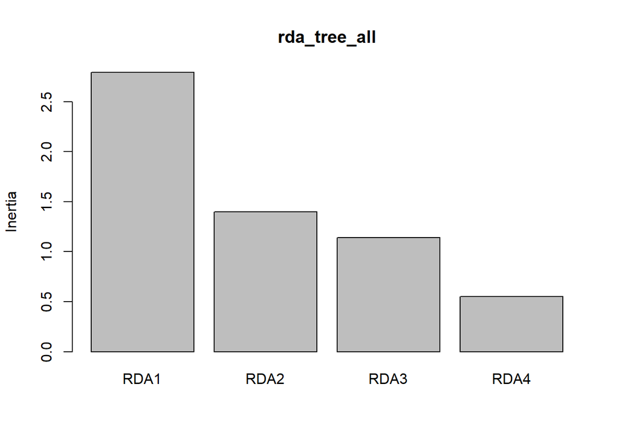

```r
screeplot(rda_tree_all)
```

#### 10. Percentage explained by constrained and unconstrained variables.

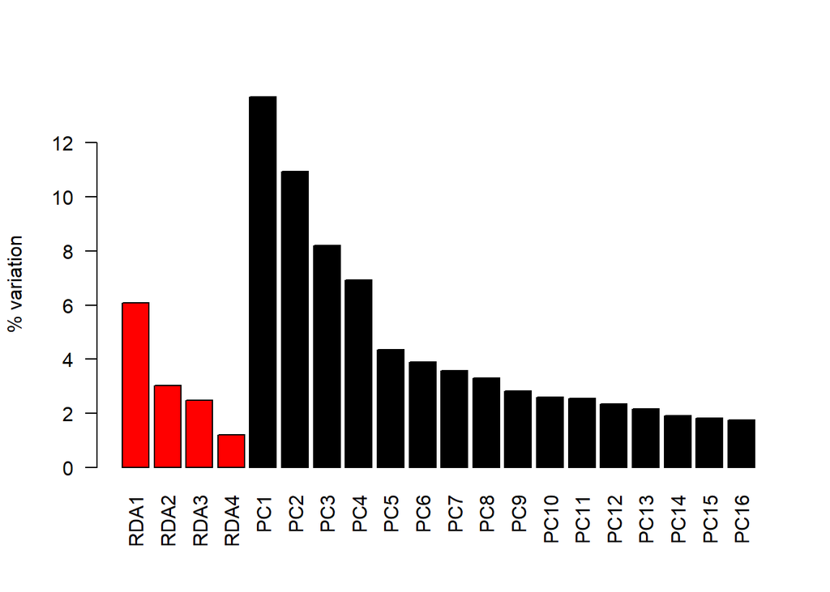

```r
constrained_eig <- rda_tree_all$CCA$eig/rda_tree_all$tot.chi*100
unconstrained_eig <- rda_tree_all$CA$eig/rda_tree_all$tot.chi*100
expl_var <- c(constrained_eig, unconstrained_eig)
barplot (expl_var[1:20], col = c(rep ('red', length (constrained_eig)), rep ('black', length (unconstrained_eig))),
         las = 2, ylab = '% variation')
```

#### 11. Ordination plots

Scaling 1 (distance biplot): Se prioriza que la distancia entre objetos en el grafico respete tanto como sea posible las distancias euclidias de la matriz original. Los angulos entre vectores (variables) pueden ser distorsionados.

Scaling 2 (correlation biplot): Se prioriza que los angulos entre vectores respeten la correlacion original entre variables. La distancia entre objetos en el grafico puede estar distorsionada.

En resumen, utilizaremos scaling 1 si nos interesa mas ver como se diferencian los objetos, y scaling 2 si nos interesa mas ver como se relacionan las distintas variables.

https://bookdown.org/stephi_gascon/bookdown-demo-master_-_multivariant/_book/ordination.html https://fukamilab.github.io/BIO202/06-B-constrained-ordination.html

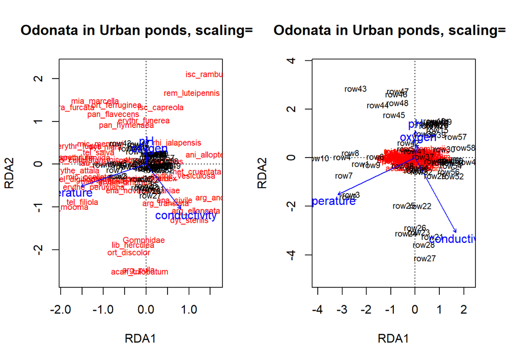

```r
par(mfrow=c(1,2))

plot(rda_tree_all, scaling=1, main="Odonata in Urban ponds, scaling=1")
plot(rda_tree_all, scaling=2, main="Odonata in Urban ponds, scaling=2")
```

#### 12. Calcular las R

```r
(R2 <- vegan::RsquareAdj(rda_tree_all)$r.squared)
```

```
## [1] 0.1278864
```

```r
(R2adj <- vegan::RsquareAdj(rda_tree_all)$adj.r.squared)
```

```
## [1] 0.06206654
```

#### 13a Testing the global significance of RDA

```r
set.seed(1)
vegan::anova.cca(rda_tree_all, step=1000)
```

```
## Permutation test for rda under reduced model
## Permutation: free
## Number of permutations: 999
##
## Model: rda(formula = spec.hel ~ temperature + oxygen + pH + conductivity, data = env_1, scale = T)
##          Df Variance     F Pr(>F)
## Model     4    5.883 1.943  0.001 ***
## Residual 53   40.117
## ---
## Signif. codes:  0 '***' 0.001 '**' 0.01 '*' 0.05 '.' 0.1 ' ' 1
```

#### 13b Testing the significance of CCA axes (at least the first two or three should present a significant p value)

Hint Argument “step” gives the minimal number of permutations requested to assess if the F value of a test is obviously significant or not

```r
set.seed(1)
vegan::anova.cca(rda_tree_all, by='axis', step=1000)
```

```
## Permutation test for rda under reduced model
## Forward tests for axes
## Permutation: free
## Number of permutations: 999
##
## Model: rda(formula = spec.hel ~ temperature + oxygen + pH + conductivity, data = env_1, scale = T)
##          Df Variance      F Pr(>F)
## RDA1      1    2.793 3.6900  0.002 **
## RDA2      1    1.397 1.8452  0.169
## RDA3      1    1.142 1.5090  0.218
## RDA4      1    0.551 0.7276  0.799
## Residual 53   40.117
## ---
## Signif. codes:  0 '***' 0.001 '**' 0.01 '*' 0.05 '.' 0.1 ' ' 1
```

#### 13c Testing the significance of terms (environmental variables)

Hint Argument “step” gives the minimal number of permutations requested to assess if the F value of a test is obviously significant or not

```r
vegan::anova.cca(rda_tree_all, by='terms', step=1000)
```

```
## Permutation test for rda under reduced model
## Terms added sequentially (first to last)
## Permutation: free
## Number of permutations: 999
##
## Model: rda(formula = spec.hel ~ temperature + oxygen + pH + conductivity, data = env_1, scale = T)
##              Df Variance      F Pr(>F)
## temperature   1    2.475 3.2697  0.001 ***
## oxygen        1    1.174 1.5516  0.075 .
## pH            1    0.615 0.8123  0.677
## conductivity  1    1.619 2.1384  0.020 *
## Residual     53   40.117
## ---
## Signif. codes:  0 '***' 0.001 '**' 0.01 '*' 0.05 '.' 0.1 ' ' 1
```